# Detección de anomalías - trabajo final

Maria Lucia Guastoni

13/5/2021

# 1. Introducción

El objetivo del presente trabajo es detectar anomalías en el set de datos “Breast Cancer Wisconsin (Diagnostic)”.

Este dataset consta de 11 variables, todas numéricas, en donde la primera variable corresponde al ID de la observación y las siguientes variables son:

2. Clump Thickness
3. Uniformity of Cell Size
4. Uniformity of Cell Shape
5. Marginal Adhesion
6. Single Epithelial Cell Size
7. Bare Nuclei
8. Bland Chromatin
9. Normal Nucleoli
10. Mitoses
11. Class

Las features de 2 a 10 toman valores enteros en un rango de 1 a 10, mientras que la variable de clase toma dos valores: 2 indica un diagnóstico benigno y 4 un diagnóstico maligno.

Para lograr el objetivo, se aplicarán tres técnicas distintas de detección de outliers: `DBSCAN`, `Expectation Maximization` y `Local Outlier Factor`.

El trabajo está estructurado en 4 secciones: la presente sección introductoria, la segunda correspondiente a la carga y limpieza de los datos, la tercera en donde se aplican los algoritmos anteriormente mencionados, y finalmente la comparación entre los mismos y la conclusión.

# 2. Carga de los datos

```r
data <- read.table("../anomalias/breast-cancer-wisconsin.data", sep = ",")
colnames(data) = c("id", "clump_thickness", "uniformity_cell_size", "uniformity_cell_shape",
                 "marginal_adhesion", "single_epithelial_cell_size", "bare_nuclei",
                 "bland_chromatin", "normal_nucleoli", "mitoses", "class")
head(data)
```

```
       id clump_thickness uniformity_cell_size uniformity_cell_shape
1 1000025               5                    1                     1
2 1002945               5                    4                     4
3 1015425               3                    1                     1
4 1016277               6                    8                     8
5 1017023               4                    1                     1
6 1017122               8                   10                    10
  marginal_adhesion single_epithelial_cell_size bare_nuclei bland_chromatin
1                 1                           2           1               3
2                 5                           7          10               3
3                 1                           2           2               3
4                 1                           3           4               3
5                 3                           2           1               3
6                 8                           7          10               9
  normal_nucleoli mitoses class
1               1       1     2
2               2       1     2
3               1       1     2
4               7       1     2
5               1       1     2
6               7       1     4
```

```r
str(data)
```

```
'data.frame':   699 obs. of  11 variables:
 $ id                         : int  1000025 1002945 1015425 1016277 1017023 1017122 1018099 1018561 1033078 1033078 ...
 $ clump_thickness            : int  5 5 3 6 4 8 1 2 2 4 ...
 $ uniformity_cell_size       : int  1 4 1 8 1 10 1 1 1 2 ...
 $ uniformity_cell_shape      : int  1 4 1 8 1 10 1 2 1 1 ...
 $ marginal_adhesion          : int  1 5 1 1 3 8 1 1 1 1 ...
 $ single_epithelial_cell_size: int  2 7 2 3 2 7 2 2 2 2 ...
 $ bare_nuclei                : chr  "1" "10" "2" "4" ...
 $ bland_chromatin            : int  3 3 3 3 3 9 3 3 1 2 ...
 $ normal_nucleoli            : int  1 2 1 7 1 7 1 1 1 1 ...
 $ mitoses                    : int  1 1 1 1 1 1 1 1 5 1 ...
 $ class                      : int  2 2 2 2 2 4 2 2 2 2 ...
```

```r
summary(data)
```

```
       id           clump_thickness  uniformity_cell_size uniformity_cell_shape
 Min.   :   61634   Min.   : 1.000   Min.   : 1.000       Min.   : 1.000
 1st Qu.:  870688   1st Qu.: 2.000   1st Qu.: 1.000       1st Qu.: 1.000
 Median : 1171710   Median : 4.000   Median : 1.000       Median : 1.000
 Mean   : 1071704   Mean   : 4.418   Mean   : 3.134       Mean   : 3.207
 3rd Qu.: 1238298   3rd Qu.: 6.000   3rd Qu.: 5.000       3rd Qu.: 5.000
 Max.   :13454352   Max.   :10.000   Max.   :10.000       Max.   :10.000
 marginal_adhesion single_epithelial_cell_size bare_nuclei
 Min.   : 1.000    Min.   : 1.000              Length:699
 1st Qu.: 1.000    1st Qu.: 2.000              Class :character
 Median : 1.000    Median : 2.000              Mode  :character
 Mean   : 2.807    Mean   : 3.216
 3rd Qu.: 4.000    3rd Qu.: 4.000
 Max.   :10.000    Max.   :10.000
 bland_chromatin  normal_nucleoli     mitoses           class
 Min.   : 1.000   Min.   : 1.000   Min.   : 1.000   Min.   :2.00
 1st Qu.: 2.000   1st Qu.: 1.000   1st Qu.: 1.000   1st Qu.:2.00
 Median : 3.000   Median : 1.000   Median : 1.000   Median :2.00
 Mean   : 3.438   Mean   : 2.867   Mean   : 1.589   Mean   :2.69
 3rd Qu.: 5.000   3rd Qu.: 4.000   3rd Qu.: 1.000   3rd Qu.:4.00
 Max.   :10.000   Max.   :10.000   Max.   :10.000   Max.   :4.00
```

Se observa que la variable 7 tiene formato “character”. Mirando el dataset, puede verse que la misma contiene valores “?”:

```r
length(data$bare_nuclei[data$bare_nuclei == "?"])
```

```
[1] 16
```

Concretamente, hay 16 valores faltantes. Se le da formato de “missing value” a estas observaciones:

```r
data[ data == "?" ] <- NA
data$bare_nuclei <- as.integer(data$bare_nuclei)
summary(data$bare_nuclei)
```

```
   Min. 1st Qu.  Median    Mean 3rd Qu.    Max.    NA's
  1.000   1.000   1.000   3.545   6.000  10.000      16
```

Ahora la variable “bare_nuclei” tiene formato integer y 16 valores faltantes.

Se eliminan las observaciones con valores faltantes, ya que representan sólo el 2.2889843% del total.

```r
data <- data[complete.cases(data$bare_nuclei), ]
```

También se desea analizar la existencia de casos/ filas duplicadas. Para ello, con la función `distinct` se identifica la cantidad de filas no duplicadas:

```r
nrow(data %>% distinct())
```

```
[1] 675
```

Dado que el dataset tiene 683 observaciones, existen 8 filas duplicadas. Luego, también se desea saber si la variable ID tiene todos valores únicos o existen duplicados:

```r
n_distinct(data$id)
```

```
[1] 630
```

```r
head(data %>% group_by(id) %>%
  filter(n() > 1) %>% count)
```

```
# A tibble: 6 x 2
# Groups:   id [6]
      id     n
   <int> <int>
1 320675     2
2 385103     2
3 411453     2
4 466906     2
5 493452     2
6 560680     2
```

Con 630 IDs únicos y 683 observaciones, se deduce que hay 53 IDs duplicados. Dado que las observaciones, es decir, cada fila, corresponde a casos clinicos que han sido registrados desde enero de 1989 hasta noviembre de 1991, se supone que los casos que tienen IDs duplicados se tratan de la evoluación de los mismos pacientes a lo largo del tiempo, siendo las filas duplicadas pacientes cuyos valores de las variables no se han modificado con el tiempo. Por lo tanto, no se eliminará ninguna de las observaciones.

A continuación se evalúa si los datos están desbalanceados con respecto a la variable de clase:

```r
table(data$class)
```

```
  2   4
444 239
```

```r
round(prop.table(table(data$class)),2)
```

```
   2    4
0.65 0.35
```

# 3. Detección de anomalías

## 3.1 PCA

Para comenzar, es necesario estandarizar los datos y luego calcular la matriz de distancias, que mide la distancia euclídea entre cada par de observaciones:

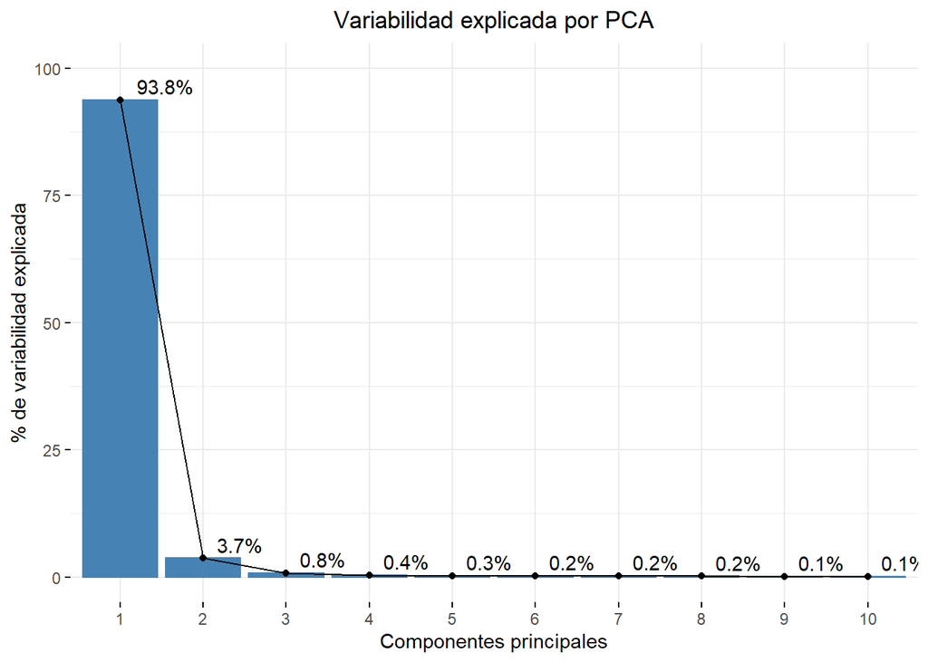

```r
x <- data %>% select(-c(1)) %>% scale
distance_matrix <- as.matrix(dist(x))
data.pca <- prcomp(distance_matrix)

fviz_eig(data.pca, addlabels=TRUE, hjust = -0.3) +
  ylim(0, 100) +
  labs(title = "Variabilidad explicada por PCA",
       x = "Componentes principales", y = "% de variabilidad explicada") +
  theme(plot.title = element_text(hjust = 0.5))
```

El gráfico muestra que el primer componente explica un 93.8% de la variabilidad total, mentras que el segundo un 3.7%. Entre ambos suman un 97,5%. Se grafican los datos en las dos dimensiones provistas por los dos primeros componentes:

```r
plotting = data.table(data.pca$x[, 1:2])
plotting[, Observacion := seq(1,nrow(data))]
plotting[, class := data$class]
```

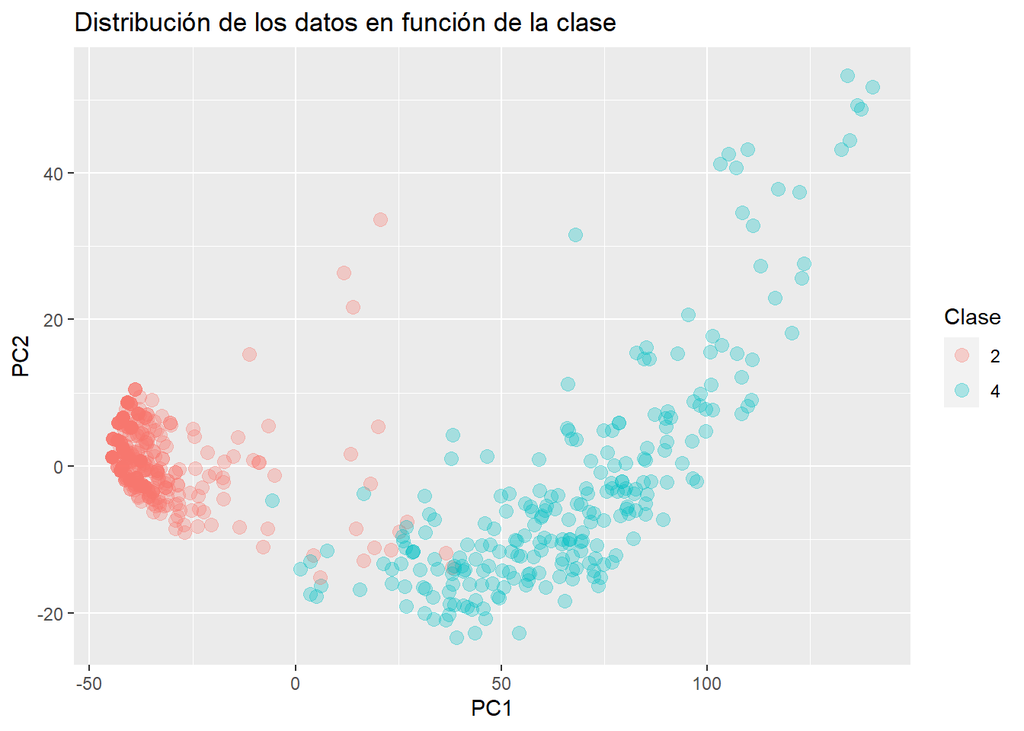

```r
ggplot(plotting, aes(x = PC1, y = PC2,color = as.factor(class))) +
  geom_point(size = 3, alpha = 0.3) +
  labs(title = "Distribución de los datos en función de la clase", color = "Clase")
```

Se observa claramente que los datos están agrupados en función de la clase, aunque existen algunos puntos que están solapados entre las dos clases, así como observaciones que se encuentran alejadas del clúster.

Pareciera que valores de PC1 menores a 0 corresponden a la clase benigna y mayores a 0 a la clase maligna.

## 3.2 `DBSCAN`

Este algoritmo se basa en la densidad de las observaciones para formar clusters, y de este modo detectar outliers, es decir, observaciones que no pertenecen a ningún cluster.

Hay dos parámetros que es necesario escoger. Por un lado, “eps”, el radio en el cual se buscarán vecinos. Por otro lado, “minPts”, el número mínimo de observaciones que debe contener el área definida por el radio (eps) para que un punto sea considerado central y no outlier.

A continuación se evalúa el algoritmo, implementando diferentes combinaciones de los paramétros:

```r
dbscan(x, eps = 2, minPts = 3)
```

```
DBSCAN clustering for 683 objects.
Parameters: eps = 2, minPts = 3
The clustering contains 3 cluster(s) and 51 noise points.

  0   1   2   3
 51 438 191   3

Available fields: cluster, eps, minPts
```

```r
dbscan(x, eps = 2, minPts = 4)
```

```
DBSCAN clustering for 683 objects.
Parameters: eps = 2, minPts = 4
The clustering contains 2 cluster(s) and 55 noise points.

  0   1   2
 55 438 190

Available fields: cluster, eps, minPts
```

```r
dbscan(x, eps = 3, minPts = 3)
```

```
DBSCAN clustering for 683 objects.
Parameters: eps = 3, minPts = 3
The clustering contains 1 cluster(s) and 2 noise points.

  0   1
  2 681

Available fields: cluster, eps, minPts
```

Eps = 2 y minPts = 3

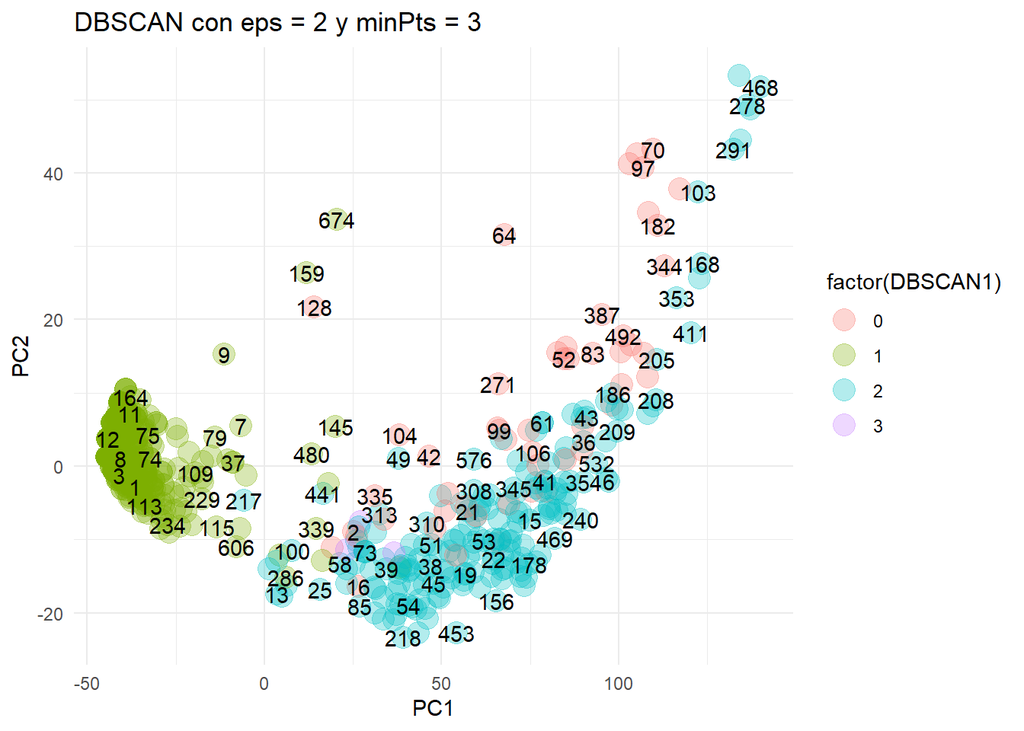

```r
dbscan1 <- dbscan(x, eps = 2, minPts = 3)
plotting[, DBSCAN1 := dbscan1$cluster]
ggplot(plotting, aes(x = PC1, y = PC2)) +
  geom_point(aes(colour = factor(DBSCAN1)), size = 5, alpha = 0.3) +
  geom_text(aes(label = Observacion), check_overlap = TRUE) +
  labs(title = "DBSCAN con eps = 2 y minPts = 3")+
  theme_minimal()
```

Efectivamente, `DBSCAN` identifica los grupos correspondientes a las etiquetas beningno/maligno, asi como un conjunto de outliers que pareciera bordear el área superior del clúster “maligno”, y otro conjunto de outliers, el clúster 3, con sólo tres casos, que está ubicado en la zona de solapamiento de los clústers correspondientes a las etiquetas. Paraciera que aquí el algoritmo sobreajusta los datos.

Eps = 2 y minPts = 4

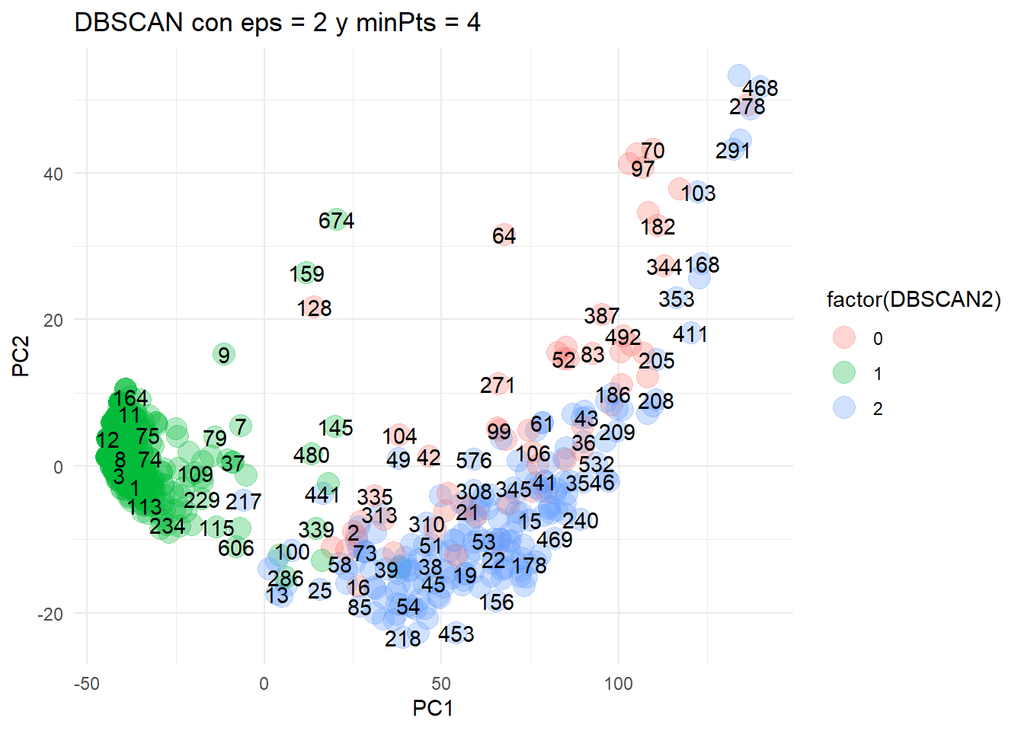

```r
dbscan2 <- dbscan(x, eps = 2, minPts = 4)
plotting[, DBSCAN2 := dbscan2$cluster]
ggplot(plotting, aes(x = PC1, y = PC2)) +
  geom_point(aes(colour = factor(DBSCAN2)), size = 5, alpha = 0.3) +
  geom_text(aes(label = Observacion), check_overlap = TRUE) +
  labs(title = "DBSCAN con eps = 2 y minPts = 4") +
  theme_minimal()
```

Esta combinación es igual a la anterior pero sin distinguir los 3 puntos en la zona de solapamiento de los clústers 1 y 2, por tanto parece un buen equilibrio entre los dos modelos anteriores.

```r
plotting <- select(plotting, -c(5))
```

## 3.3 Expectation Maximization

`Expectation Maximization` es un algoritmo no supervisado de clustering, y tiene en cuenta la varianza y la orientación de los objetos para encontrar “subespacios similares”.

El único parámetro que debe definirse es `G`, el número de clústers. Se probará la función con 3 y 4 grupos.

G = 3

```r
exm1 <-Mclust(x, G = 3)
summary(exm1)
```

```
----------------------------------------------------
Gaussian finite mixture model fitted by EM algorithm
----------------------------------------------------

Mclust VII (spherical, varying volume) model with 3 components:

 log-likelihood   n df      BIC       ICL
      -3888.261 683 35 -8004.95 -8012.625

Clustering table:
  1   2   3
235 279 169
```

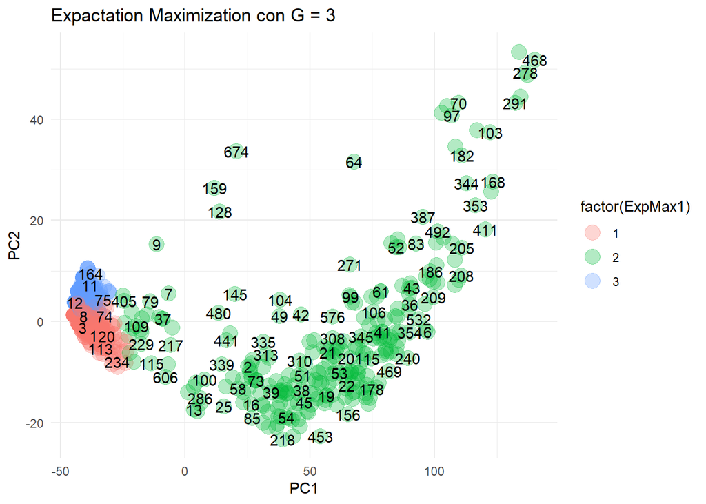

```r
plotting[, ExpMax1 := exm1$classification]
ggplot(plotting, aes(x = PC1, y = PC2)) +
  geom_point(aes(colour = factor(ExpMax1)), size = 5, alpha = 0.3) +
  geom_text(aes(label = Observacion), check_overlap = TRUE) +
  labs(title = "Expactation Maximization con G = 3")+
  theme_minimal()
```

Se observa una nueva forma de agrupación que no había surgido con `DBSCAN`, con un clúster en la parte izquierda de la nube de puntos.

G = 4

```r
exm2<-Mclust(x, G = 4)
summary(exm2)
```

```
----------------------------------------------------
Gaussian finite mixture model fitted by EM algorithm
----------------------------------------------------

Mclust EII (spherical, equal volume) model with 4 components:

 log-likelihood   n df      BIC       ICL
      -7089.865 683 44 -14466.9 -14915.35

Clustering table:
  1   2   3   4
 64 238 381   0
```

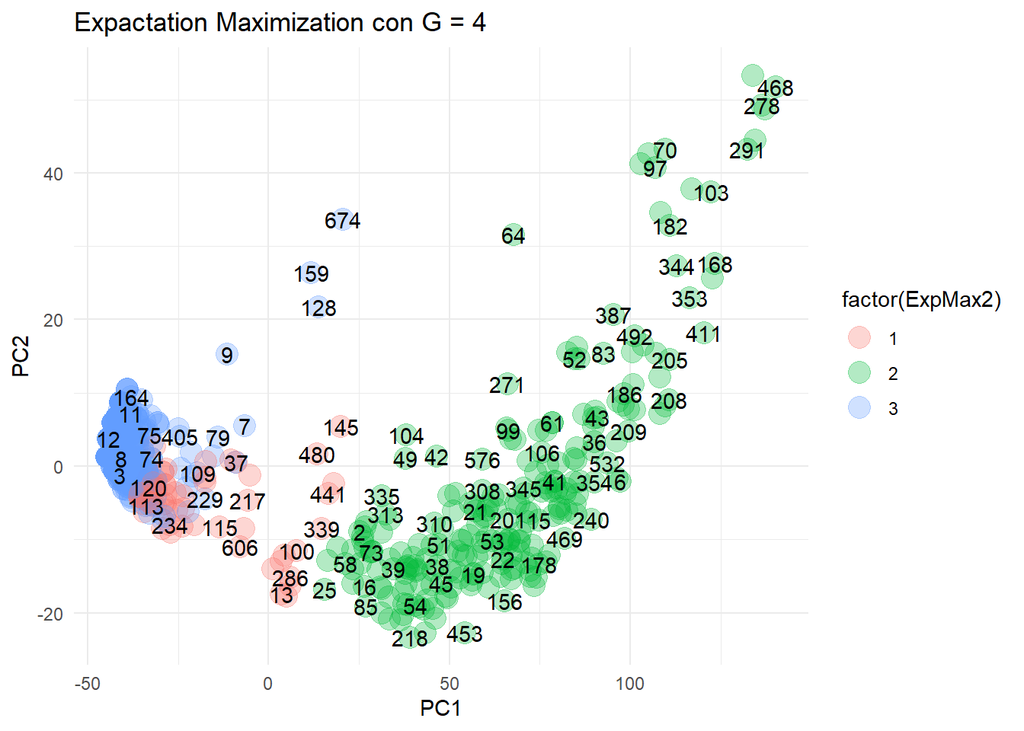

```r
plotting[, ExpMax2 := exm2$classification]
ggplot(plotting, aes(x = PC1, y = PC2)) +
  geom_point(aes(colour = factor(ExpMax2)), size = 5, alpha = 0.3) +
  geom_text(aes(label = Observacion), check_overlap = TRUE) +
  labs(title = "Expactation Maximization con G = 4")+
  theme_minimal()
```

El algoritmo no logra identificar cuatro grupos en los datos. Sin embargo, resulta muy interesante la disposición de los clústers: los dos correspondientes a las etiquetas y el tercero en el área de solapamiento de estas dos, una muy buena aproximación a lo que se observó cuando se aplicó `PCA` con las etiquetas de los datos.

```r
plotting <- select(plotting, -c(6))
```

## 3.4 Local Outlier Factor

En esta sección se aplica `Local Outlier Factor` (LOF), un algoritmo que identifica outliers en función de la densidad de los puntos. La densidad local de un punto es comparada con la de sus vecinos: si la densidad local es significativamente menor que la de los vecinos, y por tanto se tiene un valor LOF superior a la unidad, se podría estar en presencia de un outlier.

A continuación se calcula el score LOF, considerando valores de k (cantidad de vecinos más cercanos) = 30,32,34,36,38 y 40.

Cabe aclarar que se han seleccionado valores de k superiores a 30 porque para valores menores, el algoritmo arroja resultados con valor “infinito” o NA. Aprentemente, esto sucede cuando hay varios valores iguales en el conjunto de k vecinos más cercanos. Dado que las variables del dataset sólo toman valores entre 1 y 10, hay muchos valores repetidos en cada variable.

Se aplica a continuación el modelo evaluado en los valores anteriormente especificados:

```r
obs.scores.lof <- lof(x, k=seq(30,40,2))
head(obs.scores.lof)
```

```
            30        32        34        36       38       40
[1,] 1.0211312 1.0100115 1.0025597 1.0071948 1.005687 1.006737
[2,] 1.3160651 1.3878742 1.4666664 1.4595490 1.495516 1.517836
[3,] 1.0960586 1.0947544 1.0685827 1.1668259 1.166109 1.156878
[4,] 1.5399982 1.5826976 1.5848675 1.6015117 1.618002 1.643349
[5,] 1.6486833 1.5998482 1.5864423 1.5643135 1.560180 1.533657
[6,] 0.9939841 0.9943024 0.9959356 0.9984905 1.003389 1.002364
```

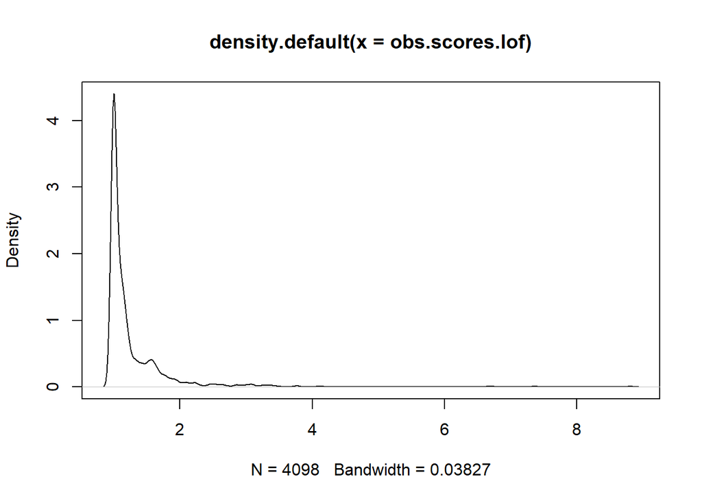

```r
plot(density(obs.scores.lof))
```

```r
plotting <- cbind(plotting, obs.scores.lof)
names(plotting) <- c("PC1","PC2","Observacion","class", "DBSCAN",  "ExpMax","lof30","lof32","lof34","lof36","lof38","lof40")

colnames <- c("lof30","lof32","lof34","lof36","lof38","lof40")

for (i in colnames){
  plotting[[i]] <- as.factor(ifelse(plotting[[i]] > 1, 0,1))
}
```

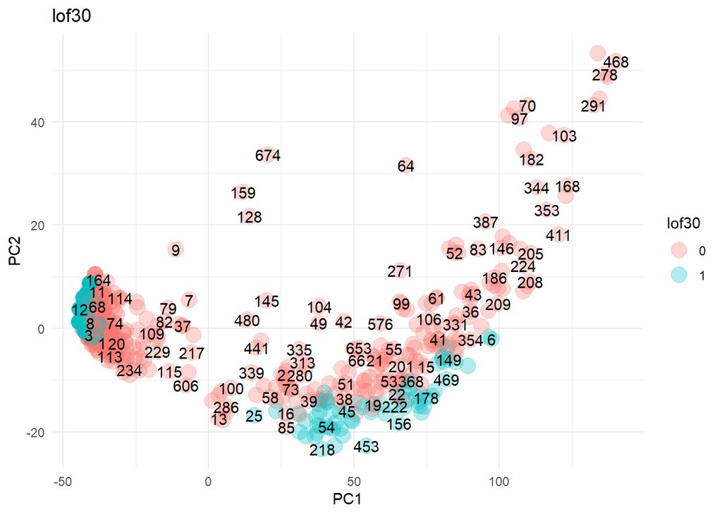

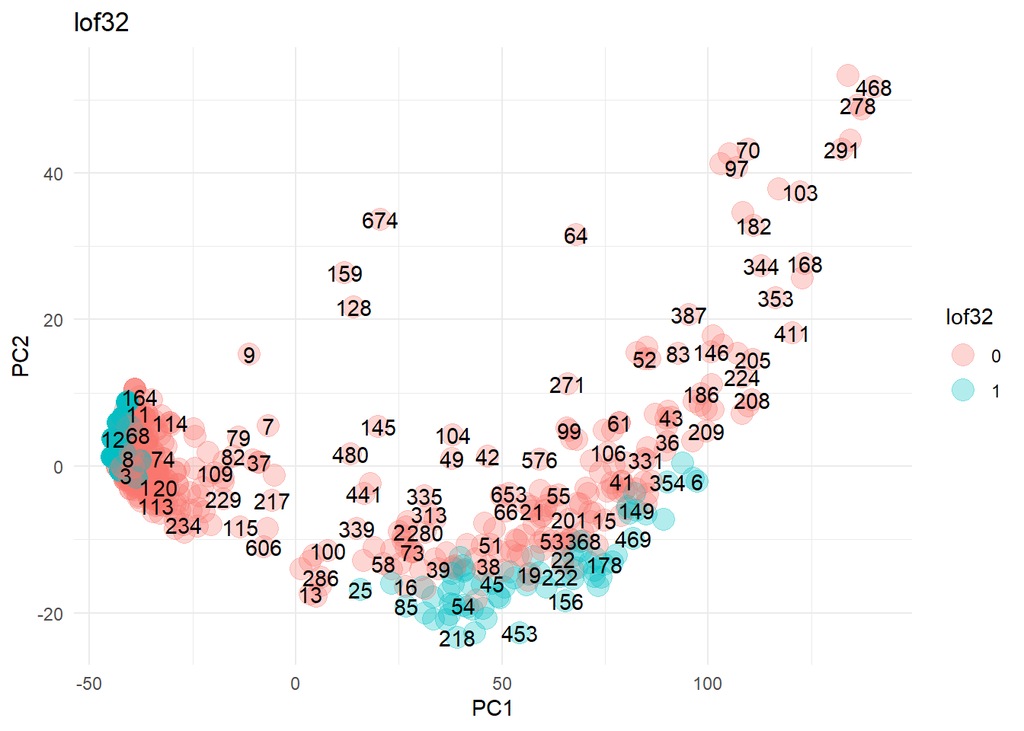

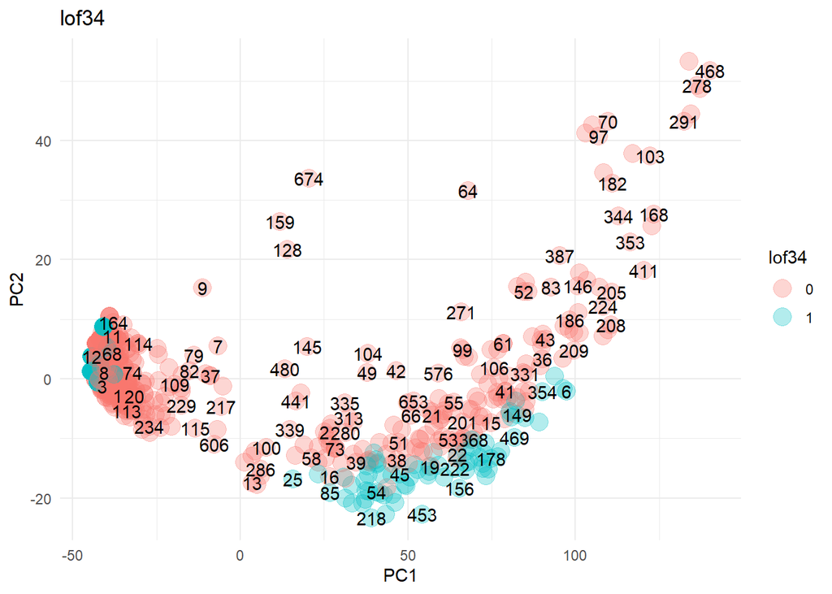

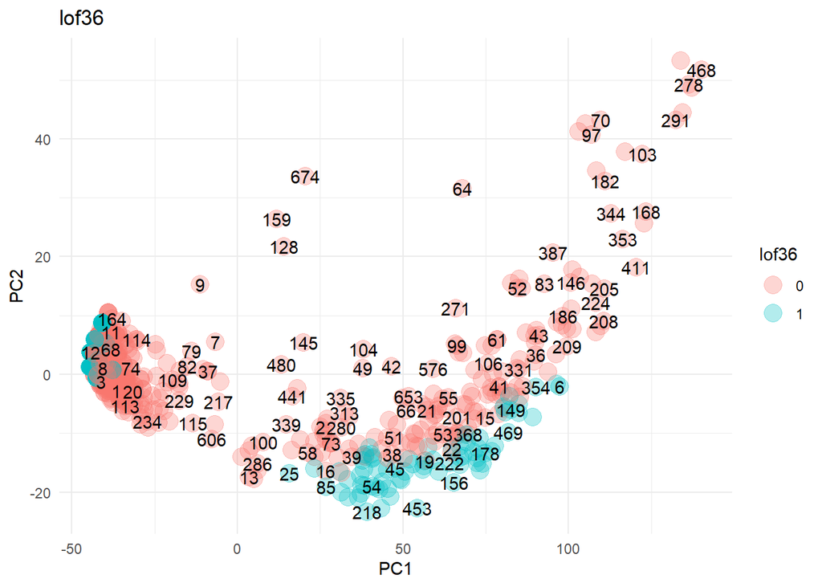

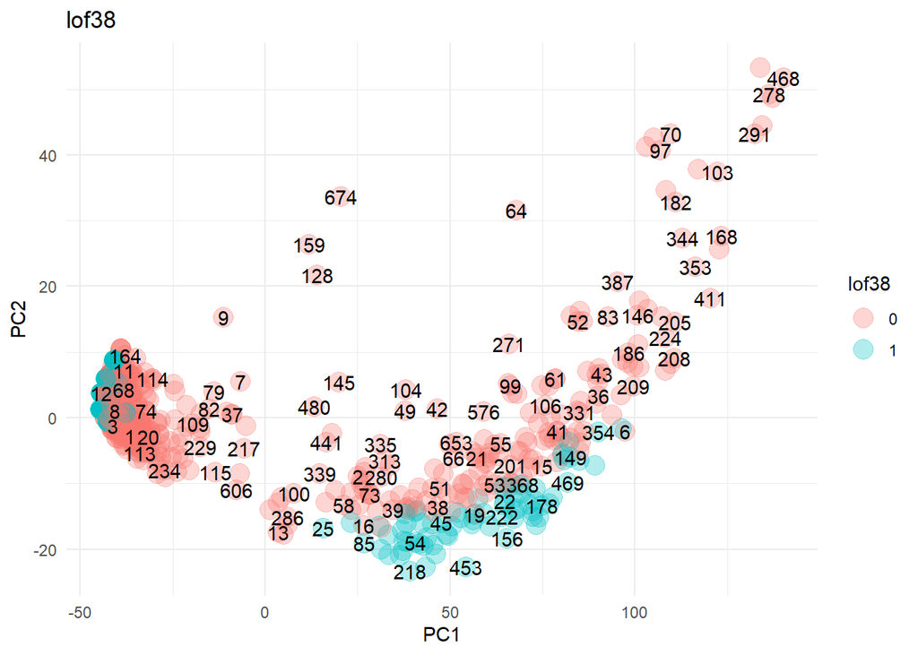

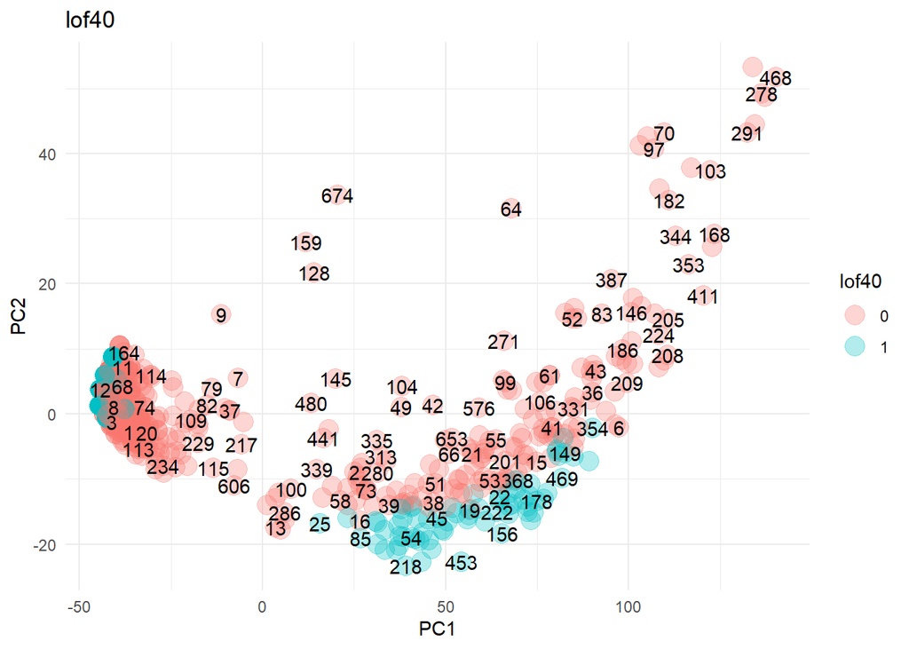

```r
for(i in colnames){
  plt <- ggplot(plotting, aes(x = PC1, y = PC2)) +
  geom_point(aes_string(colour = i), size = 5, alpha = 0.3) +
  geom_text(aes(label = Observacion), check_overlap = TRUE) +
  theme_minimal()+
  labs(title = i)
  print(plt)
  Sys.sleep(2)
}
```

Puede verse que las clasificaciones del modelo LOF son bastante similares, variando en función de pocas observaciones.

# 4. Conclusión

Luego de haber analizado los datos en función de tres algoritmos de detección de anomalías, `DBSCAN`, `Expectation Maximization` y `LOF`, se llega a la conclusión de que la mejor aproximación es la brindada por `Expectation Maximization` con G=4. Esta elección se realiza considerando como anomalías las observaciones de cada clase que se encuentran solapadas o ubicadas en el área correspondiente a la otra clase.

A continuación se muestran el gráfico con las observaciones clasificadas según la clase y el gráfico con la clasificación que arroja `Expectation Maximization` con G=4.

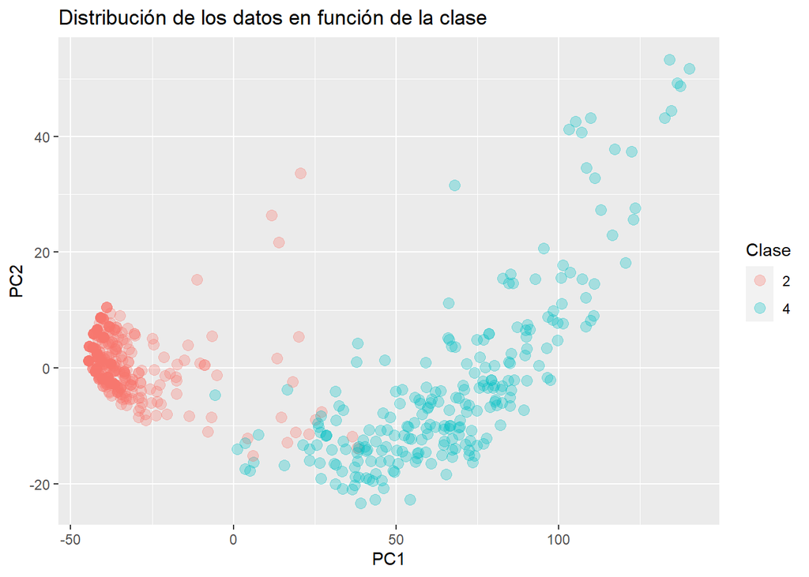

```r
ggplot(plotting, aes(x = PC1, y = PC2,color = as.factor(class))) +
  geom_point(size = 3, alpha = 0.3) +
  labs(title = "Distribución de los datos en función de la clase", color = "Clase")
```

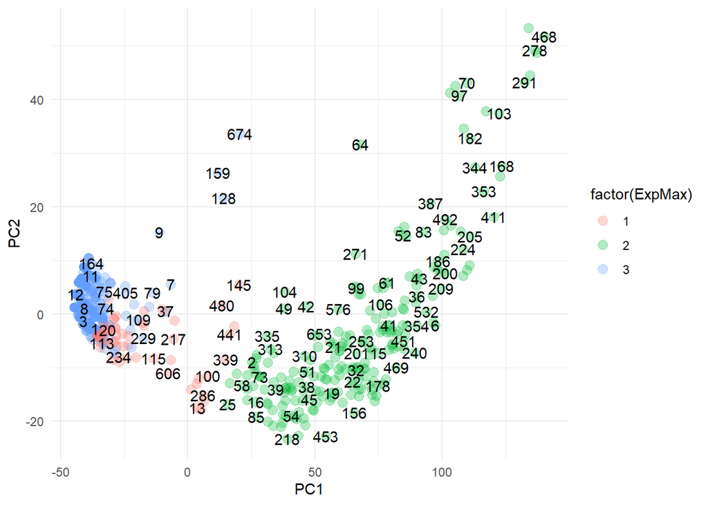

```r
ggplot(plotting, aes(x = PC1, y = PC2)) +
  geom_point(aes(colour = factor(ExpMax)), size = 3, alpha = 0.3) +
  geom_text(aes(label = Observacion), check_overlap = TRUE) +
  theme_minimal()
```

A continuación se identifica la clasificación asignada por `Expectation Maximization` a las 17 observaciones solapadas (observaciones ubicadas en zona de la otra clase):

```r
outliers_malignos <- plotting %>% filter(class == 4) %>% filter (PC1 <0)
outliers_benignos <- plotting %>% filter(class == 2) %>% filter (PC1 >0)
outliers_pca <- rbind(outliers_benignos, outliers_malignos) %>% select(c(1,2,3,4,6))
table(outliers_pca$ExpMax)
```

```
1 2 3
7 7 3
```

De las 17 anomalías, `Expectation Maximization` identifica 7 de ellas como pertenecientes al área solapada. Luego, de las restantes, 3 las asigna al clúster “benigno” y las otras 7 al clúster “maligno”.

En conclusión, el modelo escogido como el mejor para este problema resulta `Expectation Maximization` con G=4, aunque arroja 3 grupos. El mismo es el único que indentifica la zona de solapamiento entre las dos clases del dataset.